# Lab: Data Manipulation with dplyr

36-600

## Data

We’ll begin by importing some astronomical data from the 36-290 GitHub site. These data are stored in `.Rdata` format; such data are saved via `R`’s `save()` function and loaded via `R`’s `load()` function. One wrinkle here: the data are stored on the web, so we also have to apply the `url()` function.

```r
load(url("https://raw.githubusercontent.com/pefreeman/36-290/master/EXAMPLE_DATASETS/BUZZARD/Buzzard_DC1.Rdata"))
set.seed(101)
s  <- sample(nrow(df),4000)
df <- df[s,-c(7:13)]
```

`df` is a data frame with 4000 rows and 7 columns; the first six are predictor variables and the seventh, `redshift`, is the response variable. Redshift is a directly observable proxy for the distance of a galaxy from the Earth. (After all, tape measures aren’t going to help us here.) In a statistical learning exercise, we might try to determine a statistical model that optimally associates the predictor variables with the `redshift`.

# Questions

## Question 1

Apply the `dim()`, `nrow()`, `ncol()`, and `length()` functions to `df`, so as to build intuition about what these functions output. (Note: we are not using `dplyr` yet, just base `R` functions here.) Do you know why `length()` returns the value it does? Ask me or the TA if you do not. (But fill in an answer below regardless to reinforce the answer.)

```r
dim(df)
```

```
## [1] 4000    7
```

```r
nrow(df)
```

```
## [1] 4000
```

```r
ncol(df)
```

```
## [1] 7
```

```r
length(df)
```

```
## [1] 7
```

```
The reason why the function length() gives back seven is because of the fact that the way that r stores dataframes is in such a way that it stores in a matrix format and r can only read the second value of the matrix
```

## Question 2

Display the names of each column of `df`.

```r
names(df)
```

```
## [1] "u"        "g"        "r"        "i"        "z"        "y"        "redshift"
```

Time for a digression.

A *magnitude* is a logarithmic measure of brightness that is calibrated such as to be approximately zero for the brightest stars in the night sky (Sirius, Vega, etc.). Every five-unit *increase* in magnitude is a factor of 100 *decrease* in brightness. So a magnitude of 20 means the object is 100 million times fainter than a star like Vega.

Magnitudes are generally measured in particular bands. Imagine that you put a filter in front of a telescope that only lets photons of certain wavelengths pass through. You can then assess the brightness of an object at just those wavelengths. So `u` represents a magnitude determined at ultraviolet wavelengths, with `g`, `r`, and `i` representing green, red, and infrared. (The `z` and `y` are a bit further into the infrared. The names don’t represent words.)

So the predictor data consists of six magnitudes spanning from the near-UV to the near-IR.

## Question 3

Use the base `R` `summary()` function to get a textual summary of the data frame. Do you notice anything strange? (Some values you might not expect?)

```r
summary(df)
```

```
##        u               g               r               i
##  Min.   :19.55   Min.   :18.51   Min.   :18.00   Min.   :17.74
##  1st Qu.:26.37   1st Qu.:25.86   1st Qu.:25.10   1st Qu.:24.55
##  Median :27.34   Median :26.94   Median :26.29   Median :25.74
##  Mean   :33.06   Mean   :26.87   Mean   :25.88   Mean   :25.27
##  3rd Qu.:28.51   3rd Qu.:27.74   3rd Qu.:27.00   3rd Qu.:26.47
##  Max.   :99.00   Max.   :99.00   Max.   :29.41   Max.   :27.00
##        z               y            redshift
##  Min.   :17.56   Min.   :17.34   Min.   :0.03713
##  1st Qu.:24.21   1st Qu.:23.86   1st Qu.:0.49941
##  Median :25.35   Median :25.04   Median :0.74346
##  Mean   :24.98   Mean   :25.85   Mean   :0.82800
##  3rd Qu.:26.12   3rd Qu.:25.89   3rd Qu.:1.08971
##  Max.   :99.00   Max.   :99.00   Max.   :1.99975
```

```
From the summary it can be seen that the dataframe df has got some outliers being that they have some columns like u, g, z and y that have max values of 99 which seems to be a bit skewed due to the fact that the the minimum mean and median are so small
```

## dplyr

Below, we will practice using `dplyr` package functions to select rows and/or columns of a data frame. `dplyr` is part of the `tidyverse`, and is rapidly becoming the most oft-used way of transforming data. To learn more about “transformatory” functions, read through today’s class notes, then through Chapter 5 of the online version of *R for Data Science* (see the syllabus for the link, or just Google for it). In short, you can

| action | function |
| --- | --- |
| pick features by name | `select()` |
| pick observations by value | `filter()` |
| pick observations by category | `group_by()` |
| create new features | `mutate()` |
| reorder rows | `arrange()` |
| collapse rows to summaries | `summarize()` |

```r
suppressMessages(library(tidyverse))
head(df[,1:2])                         # base R
```

```
##              u       g
## 2873   23.5907 21.6827
## 108639 27.1252 26.2652
## 19665  27.4013 26.7235
## 87391  27.9354 27.0586
## 35772  27.7733 27.4076
## 46326  27.1742 26.9353
```

```r
df %>% select(.,u,g) %>% head(.)       # dplyr
```

```
##              u       g
## 2873   23.5907 21.6827
## 108639 27.1252 26.2652
## 19665  27.4013 26.7235
## 87391  27.9354 27.0586
## 35772  27.7733 27.4076
## 46326  27.1742 26.9353
```

Let’s do a few exercises here. Be sure to tap into, e.g., StackOverflow and *R for Data Science* for any help you may need.

## Question 4

Grab all data for which `i` is less than 25 and `g` is greater than 22, and output in order of increasing `y`. (Remember: you combine conditions with & for “and” and | for “or”.) Show only the first six lines of output. Note that `head()` by default shows the first six rows of the input data frame.

```r
result <- df[df$i < 25 & df$g > 22, ]
typeof(df$y)
```

```
## [1] "double"
```

```r
result_sorted <- arrange(df, df$y)
head(result_sorted)
```

```
##         u       g       r       i       z       y redshift
## 1 19.5533 18.5084 18.0035 17.7448 17.5590 17.3428 0.037134
## 2 19.8458 18.7869 18.2210 17.8609 17.6711 17.4633 0.074968
## 3 21.4308 19.7659 18.7135 18.2024 17.8596 17.5959 0.130146
## 4 21.1878 19.6717 18.5965 18.1612 17.9308 17.7205 0.191725
## 5 20.7499 19.3800 18.5199 18.1246 17.9349 17.7596 0.156207
## 6 19.9762 19.0557 18.4569 18.0945 18.0385 17.8989 0.204380
```

## Question 5

To get a quick, textual idea of how the data are distributed: select the `g` column, pipe it to the `round()` function, then pipe the output of `round()` to `table()`. You should notice something strange about the output…the same thing you should have noticed when answering Question 3.

```r
table(round(df$g))
```

```
##
##   19   20   21   22   23   24   25   26   27   28   29   30   31   32   34   99
##    5    5   27   46   99  206  388  722 1224  946  247   51   13    9    1   11
```

Time for another digression. Domain scientists are not bound by the `R` convention of using `NA` when data are “not available,” or missing. Sometimes the domain scientists will tell you what they use in place of `NA`, sometimes not. In those latter cases, one can usual infer the values. Astronomers for some reason love using -99, -9, 99, etc., to represent missing values. The values of 99 in the table you generated in Question 5 actually represent missing data.

We could change the values of 99 to `NA`, but here we will just filter those rows with values of 99 out of the data frame.

## Question 6

Use `filter()` to determine how many rows contain 99’s. Since 99’s can appear in different columns, you will need to combine conditions together with logical “and”s or “or”s. Note: only four of the six columns have 99’s in them.

```r
nrow(filter(df, u==99| g==99 | z==99| y==99))
```

```
## [1] 393
```

## Question 7

Now repeat Question 6 (in a sense), and remove all the rows that contain 99’s, saving the new data frame as `df.new`. Hint that may help: the opposite of, e.g., `u==99 | g==99` is `u!=99 & g!=99`, etc. If you apply `dim()` to the new data frame, you should see that 3607 rows are retained.

```r
df.new<-filter(df, u!=99&g!=99&z!=99&y!=99)
dim(df.new)
```

```
## [1] 3607    7
```

The data we are working with have no factor variables, so I’m going to create one on the fly:

```r
type <- rep("FAINT",nrow(df.new))
w <- which(df.new$i<25)
type[w] <- "BRIGHT"
type <- factor(type)
unique(type)
```

```
## [1] BRIGHT FAINT
## Levels: BRIGHT FAINT
```

```r
df.new <- cbind(type,df.new)
```

So I defined my factor variable using character strings, and then coerced the vector of strings into a factor variable with two levels. Note that by default, the levels order themselves into alphabetical order. You can override that default behavior if there is actually a natural ordering to your factor variables. See the documentation for `factor()` to see how to do that.

## Question 8

Use `group_by()` and `summarize()` to determine the numbers of `BRIGHT` and `FAINT` galaxies in the dataset. (If you are adventuresome: try implementing the `tally()` function instead of `summarize()`. For our purposes here, it’s actually easier.)

```r
df.new%>%group_by(type)%>%summarize(count = n())
```

```
## # A tibble: 2 × 2
##   type   count
##   <fct>  <int>
## 1 BRIGHT  1295
## 2 FAINT   2312
```

## Question 9

Repeat Question 8, but show the median value of the `u` magnitude instead of the numbers in each factor group. (You do need `summarize()` here; `tally()` won’t help you.)

```r
df.new%>%group_by(type)%>%summarize(median(u))
```

```
## # A tibble: 2 × 2
##   type   `median(u)`
##   <fct>        <dbl>
## 1 BRIGHT        25.9
## 2 FAINT         27.7
```

Time for yet another digression.

Magnitudes of galaxies at particular wavelengths are heavily influenced by two factors: physics (what is going on with the gas, dust, and stars within the galaxy itself), and distance (the further away a galaxy is, the less bright it tends to be, so the magnitude generally goes up). To attempt to mitigate (somewhat, not necessarily completely) the effect of distance, astronomers often use *colors*, which are differences in magnitude for two adjacent filters.

## Question 10

Use `mutate()` to define two new columns for `df.new`: `gr`, which would be the `g` magnitude minus the `r` magnitude, and `ri`, for `r` and `i`. Save your result as `df.newer`.

```r
gr<-(df.new$g-df.new$r)
df.newer<-df.new%>%mutate(gr=g-r, ri=r-i)
```

## Question 11

Are the mean values of `g-r` and `r-i` roughly the same for `BRIGHT` galaxies versus `FAINT` ones? Heck if I know. Use `dplyr` functions to attempt to answer this question.

```r
df.newer%>%group_by(type)%>%summarize(mean(gr), mean(ri))
```

```
## # A tibble: 2 × 3
##   type   `mean(gr)` `mean(ri)`
##   <fct>       <dbl>      <dbl>
## 1 BRIGHT      0.942      0.620
## 2 FAINT       0.694      0.558
```

## Question 12

Let’s go back to hypothesis testing for a moment. Let’s extract two vectors of data from `df.newer`:

```r
gr.faint  <- df.newer$gr[df.newer$type=="FAINT"]
gr.bright <- df.newer$gr[df.newer$type=="BRIGHT"]
```

The first vector has all the `g-r` colors for faint galaxies, and the second vector has all the ones for bright galaxies. The code here *should* be familiar given what we covered in Week 01, but if you are not sure what this code is doing, call me or the TA over.

Here are the histograms for `gr.faint` and `gr.bright`:

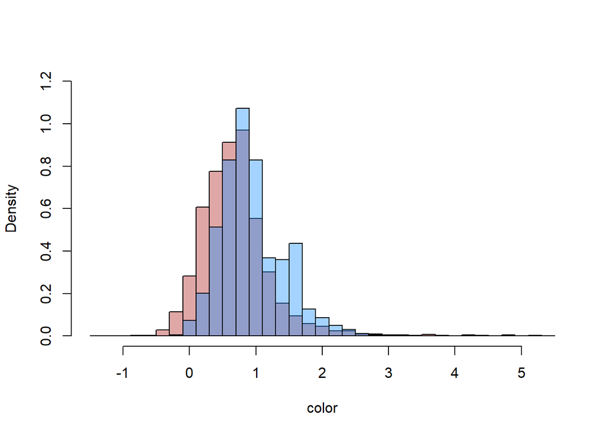

```r
hist(gr.faint,prob=TRUE,main=NULL,col=alpha("firebrick",0.4),ylim=c(0,1.2),xlab="color",breaks=seq(-1.5,5.5,by=0.2))
hist(gr.bright,prob=TRUE,main=NULL,col=alpha("dodgerblue",0.4),breaks=seq(-1.5,5.5,by=0.2),add=TRUE)
```

Now: test the hypothesis that the means of the distributions that `gr.faint` and `gr.bright` are sampled from are the same. Use a two-sample $t$ test. What do you conclude? Is a two-sample $t$ test actually strictly appropriate here? How would you know? (Even if the answer is no, do the $t$ test anyway.)

```r
t.test(gr.faint, gr.bright, alternative = 'two.sided')
```

```
##
##  Welch Two Sample t-test
##
## data:  gr.faint and gr.bright
## t = -14.389, df = 2979.8, p-value < 2.2e-16
## alternative hypothesis: true difference in means is not equal to 0
## 95 percent confidence interval:
##  -0.2816093 -0.2140635
## sample estimates:
## mean of x mean of y
## 0.6942116 0.9420480
```

[output not shown]